# San Juan Background

Last update: 2022-09-09

### **Escapement, age and origin**

The adult age structure is primarily 3, 4 and 5 year olds. Jacks and 6 year olds contribute minimally to the population, especially in recent years.

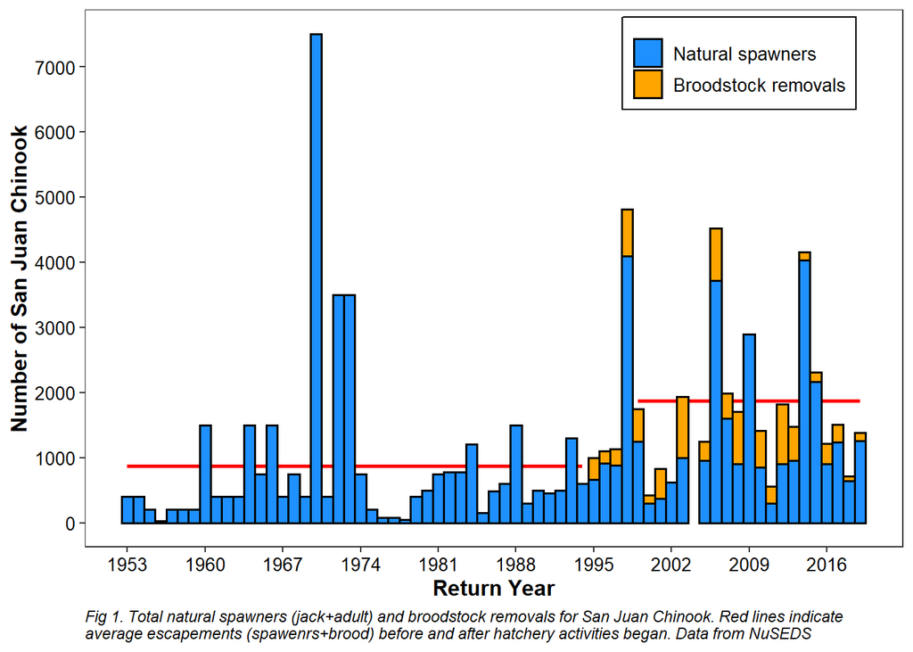

*Table 1. Age structure of San Juan Chinook (excludes tributaries). Data from NuSEDS.*

| Age | Average proportion (± SD) |
| --- | --- |
| 2 | 2.6 ± 2.1 |
| 3 | 20.8 ± 17.5 |
| 4 | 46.5 ± 23.5 |
| 5 | 30.4 ± 21.3 |
| 6 | 4.9 ± 7.4 |

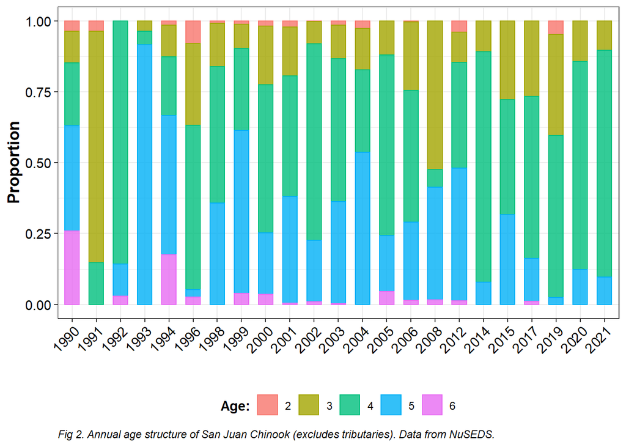

| SOURCE | SAMPLE YR | total | Hatchery origin? | FACILITY2 | n | Propn (%) |
| --- | --- | --- | --- | --- | --- | --- |
| Escapement | 2004 | 16 | Y | SAN JUAN RIVER HATCHERY | 10 | 62 |
|  |  |  | N/unk | NA | 6 | 38 |
|  | 2005 | 106 | Y | Other hatchery | 2 | 2 |
|  |  |  | Y | SAN JUAN RIVER HATCHERY | 63 | 59 |
|  |  |  | N/unk | NA | 41 | 39 |
|  | 2006 | 201 | Y | Other hatchery | 1 | 0 |
|  |  |  | Y | SAN JUAN RIVER HATCHERY | 66 | 33 |
|  |  |  | N/unk | NA | 134 | 67 |
|  | 2008 | 90 | Y | Other hatchery | 1 | 1 |
|  |  |  | N/unk | NA | 89 | 99 |
|  | 2012 | 102 | Y | Other hatchery | 3 | 3 |
|  |  |  | N/unk | NA | 99 | 97 |
|  | 2014 | 130 | Y | Other hatchery | 7 | 5 |
|  |  |  | Y | SAN JUAN RIVER HATCHERY | 111 | 85 |
|  |  |  | N/unk | NA | 12 | 9 |
|  | 2015 | 95 | Y | Other hatchery | 1 | 1 |
|  |  |  | Y | SAN JUAN RIVER HATCHERY | 76 | 80 |
|  |  |  | N/unk | NA | 18 | 19 |
|  | 2017 | 97 | Y | SAN JUAN RIVER HATCHERY | 55 | 57 |
|  |  |  | N/unk | NA | 42 | 43 |
|  | 2019 | 163 | Y | Other hatchery | 43 | 26 |
|  |  |  | N/unk | NA | 120 | 74 |
|  | 2020 | 244 | Y | Other hatchery | 1 | 0 |
|  |  |  | Y | SAN JUAN RIVER HATCHERY | 1 | 0 |
|  |  |  | N/unk | NA | 242 | 99 |
|  | 2021 | 299 | Y | Other hatchery | 2 | 1 |
|  |  |  | Y | SAN JUAN RIVER HATCHERY | 15 | 5 |
|  |  |  | N/unk | NA | 282 | 94 |
| FSC - Escapement | 2005 | 96 | Y | Other hatchery | 3 | 3 |
|  |  |  | Y | SAN JUAN RIVER HATCHERY | 53 | 55 |
|  |  |  | N/unk | NA | 40 | 42 |
|  | 2020 | 30 | N/unk | NA | 30 | 100 |

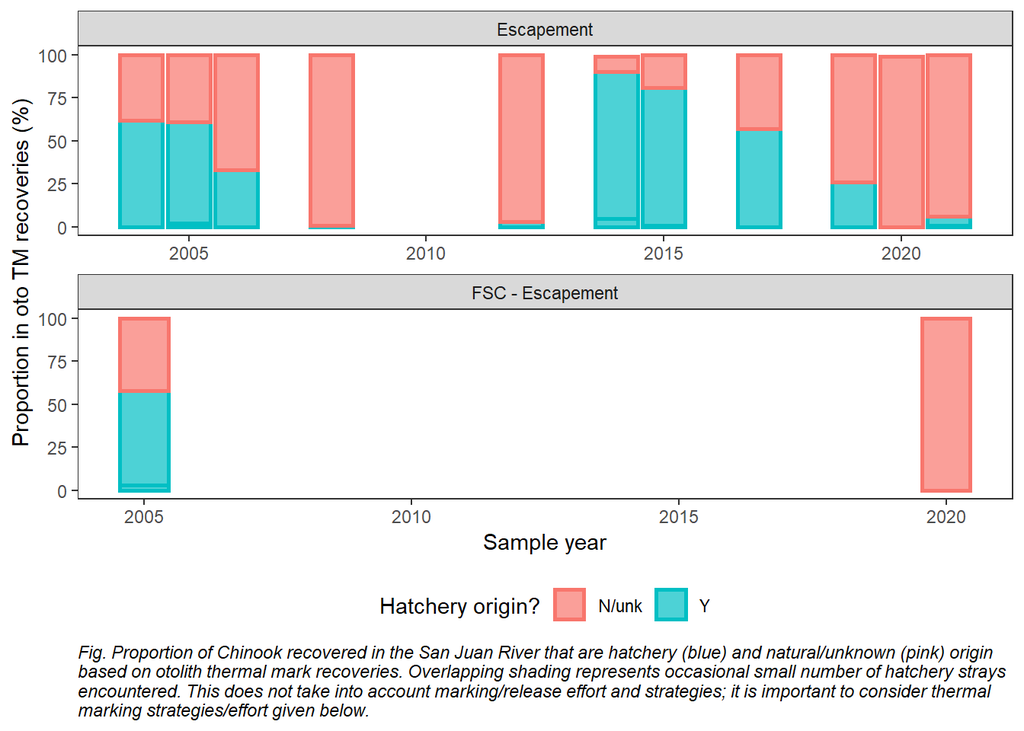

### **Enhancement activity**

The 4 Mile Creek Enhancement Society operates the 4 Mile Hatchery to enahnce San Juan chinook. The current board of directors is composed of the society members, hatchery managers, Pacheedaht and MOSAIC representatives. The hatchery is modest in its capacity to produce chinook (as well as some coho and chum). Releases are typically less than 1 million and are usually smolts (sometimes fed fry). Current release goals are approximately 460,000 smolts.

Due to water shortage issues at the hatchery in warmer months, most juveniles are transferred to the Fairy Lakepen for the remainder of their holding time. Juveniles are then released from the Fairy Lake outlet (~200m from the San Juan River). A subset are CWT’d and held at the hatchery where low water can sustain a smaller group. These fish are held at the hatchery for a brief period of time before they are transferred to a seapen off Port Renfrew where they imprint in the marine environemnt. The goal of the seapen releases is to support a terminal fishery; juveniles that have imprinted on nearshore marine waters (rather than the lake or river) are (ideally) more likely to return to these waters as adults and stage here longer than adults with a high drive to return to natal freshwater. The holding/staging of fish in coastal waters provides a fishery opportunity for Pacheedaht members.

#### Brood collection and release history

Fig 1/Fig 3 shows brood collections over time (as documented in NuSEDS). Hatchery releases from SEP are documented back to 1995, but note that MRP also contains San Juan CWT records dating back to BY 1979. From 2013-2017 all seapean releases were marked, but the seapen has not been used in recent years (although hopes to be used for BY 2022/RY 2023). The majority of San Juan chinook releases are unmarked.

*Table 2. Hatchery releases and marking information for San Juan and tributary Chinook. Data from SEP. It is assumed all broodstock was collected from the San Juan River, with different release strategy locations indicated by “Release Site Name” (Port Renfrew = juveniles reared in a sea netpen).*

| BROOD_YEAR | FACILITY_NAME | CWT_AD | AD_only | unmarked | tags_lost | total_release | CWT_AD % | AD_only % | unmarked % |
| --- | --- | --- | --- | --- | --- | --- | --- | --- | --- |
| 1995 | San Juan River H | 0 | 0 | 600,000 | 0 | 600,000 | 0 | 0 | 100 |
| 1996 |  | 0 | 0 | 410,000 | 0 | 410,000 | 0 | 0 | 100 |
| 1997 |  | 0 | 0 | 275,000 | 0 | 275,000 | 0 | 0 | 100 |
| 1998 |  | 0 | 0 | 1,275,000 | 0 | 1,275,000 | 0 | 0 | 100 |
| 1999 |  | 75,150 | 0 | 774,598 | 252 | 850,000 | 9 | 0 | 91 |
| 2000 |  | 75,429 | 0 | 149,000 | 0 | 224,429 | 34 | 0 | 66 |
| 2001 |  | 75,242 | 0 | 709,758 | 0 | 785,000 | 10 | 0 | 90 |
| 2002 |  | 0 | 0 | 772,052 | 0 | 772,052 | 0 | 0 | 100 |
| 2003 | Port Renfrew Seapen | 0 | 0 | 10,172 | 0 | 10,172 | 0 | 0 | 100 |
|  | San Juan River H | 0 | 0 | 1,064,000 | 0 | 1,064,000 | 0 | 0 | 100 |
| 2004 | Port Renfrew Seapen | 0 | 0 | 20,000 | 0 | 20,000 | 0 | 0 | 100 |
|  | San Juan River H | 0 | 0 | 980,000 | 0 | 980,000 | 0 | 0 | 100 |
| 2005 | Port Renfrew Seapen | 0 | 0 | 27,775 | 0 | 27,775 | 0 | 0 | 100 |
|  | San Juan River H | 0 | 0 | 345,500 | 0 | 345,500 | 0 | 0 | 100 |
| 2006 | Port Renfrew Seapen | 0 | 0 | 35,253 | 0 | 35,253 | 0 | 0 | 100 |
|  | San Juan River H | 0 | 0 | 949,902 | 0 | 949,902 | 0 | 0 | 100 |
| 2007 | Port Renfrew Seapen | 0 | 0 | 18,510 | 0 | 18,510 | 0 | 0 | 100 |
|  | San Juan River H | 0 | 0 | 500,000 | 0 | 500,000 | 0 | 0 | 100 |
| 2008 | Port Renfrew Seapen | 0 | 0 | 39,450 | 0 | 39,450 | 0 | 0 | 100 |
|  | San Juan River H | 0 | 0 | 906,200 | 0 | 906,200 | 0 | 0 | 100 |
| 2009 | Port Renfrew Seapen | 0 | 0 | 38,800 | 0 | 38,800 | 0 | 0 | 100 |
|  | San Juan River H | 0 | 0 | 1,000,000 | 0 | 1,000,000 | 0 | 0 | 100 |
| 2010 | Port Renfrew Seapen | 0 | 0 | 40,000 | 0 | 40,000 | 0 | 0 | 100 |
|  | San Juan River H | 0 | 0 | 800,000 | 0 | 800,000 | 0 | 0 | 100 |
| 2011 | Port Renfrew Seapen | 0 | 0 | 10,000 | 0 | 10,000 | 0 | 0 | 100 |
|  | San Juan River H | 0 | 0 | 235,000 | 0 | 235,000 | 0 | 0 | 100 |
| 2012 | Port Renfrew Seapen | 0 | 0 | 41,800 | 0 | 41,800 | 0 | 0 | 100 |
|  | San Juan River H | 0 | 0 | 990,000 | 0 | 990,000 | 0 | 0 | 100 |
| 2013 | Port Renfrew Seapen | 45,000 | 0 | 0 | 0 | 45,000 | 100 | 0 | 0 |
|  | San Juan River H | 0 | 0 | 274,000 | 0 | 274,000 | 0 | 0 | 100 |
| 2014 | Port Renfrew Seapen | 37,410 | 25 | 0 | 0 | 37,435 | 100 | 0 | 0 |
|  | San Juan River H | 0 | 0 | 200,000 | 0 | 200,000 | 0 | 0 | 100 |
| 2015 | Port Renfrew Seapen | 44,486 | 0 | 0 | 268 | 44,754 | 99 | 0 | 0 |
|  | San Juan River H | 0 | 0 | 174,598 | 0 | 174,598 | 0 | 0 | 100 |
| 2016 | Port Renfrew Seapen | 48,411 | 0 | 0 | 0 | 48,411 | 100 | 0 | 0 |
|  | San Juan River H | 0 | 0 | 494,445 | 0 | 494,445 | 0 | 0 | 100 |
| 2017 | Port Renfrew Seapen | 45,075 | 0 | 0 | 454 | 45,529 | 99 | 0 | 0 |
|  | San Juan River H | 0 | 0 | 204,370 | 0 | 204,370 | 0 | 0 | 100 |
| 2018 | Fairy Lakepen | 0 | 0 | 66,794 | 0 | 66,794 | 0 | 0 | 100 |
| 2019 | San Juan River H | 0 | 0 | 184,597 | 0 | 184,597 | 0 | 0 | 100 |
| 2020 |  | 0 | 0 | 422,512 | 0 | 422,512 | 0 | 0 | 100 |

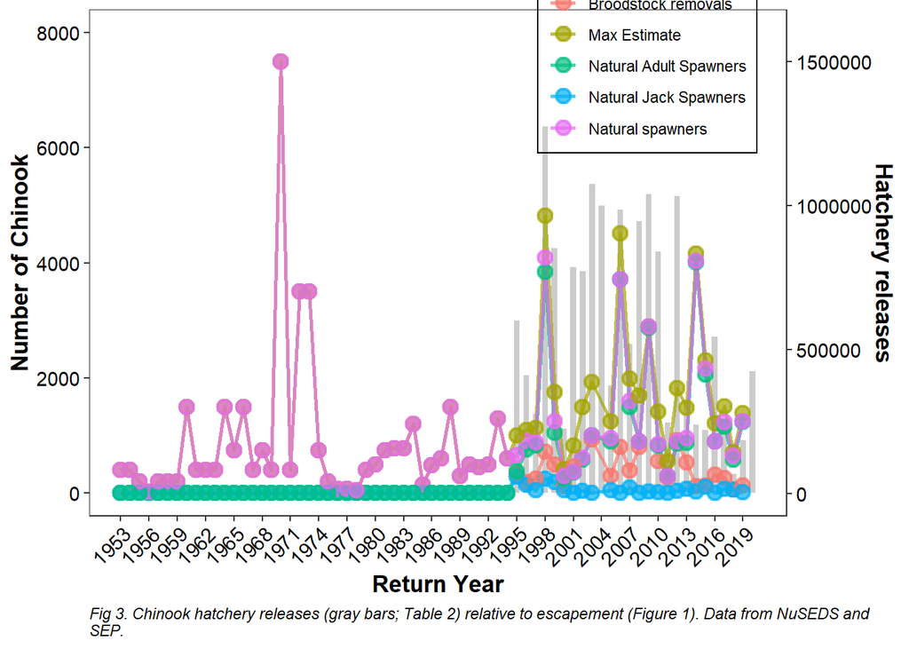

#### Thermal marking history

San Juan chinook have been thermally marked since 2010, according to reference specimens submitted in Otolith Manager. However, BYs 2014-2017 and 2020 all had “NA” quality thermal marks (as opposed to good/acceptable). This poses uncertainty for thermal mark detection in fisheries and escapement recoveries. Of those NAs in 2010-2011, the mark is listed as “NA”. Some 2014 specimens also have mark listed as NA, but the majority were “Not Marked”.

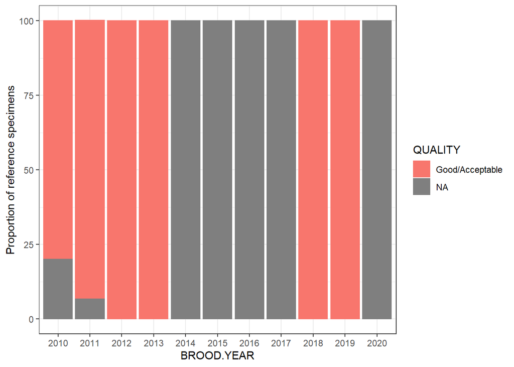

#### PBT

Parental-based tagging (PBT) is relatively new for San Juan Chinook, beginning in 2017 but only reliable since 2019. From Eric Rondeau, MGL:

> We’ve received what I believe to be nearly-complete brood in 2018-2021. I would say it is reliable from 2019-2021, as 2018 was missing sex ID information which complicates the process. We received ~1/3 of the brood in 2017, so I would anticipate a limited ability to PBT there as well, but not enough to reliably utilize… **I would suggest thought that 2019 is the first brood year I would recommend starting from, so for 2022 age 3.** We could probably go back to 2018 (age 4 for 2022) too if we can identify the records on sex of the samples submitted, or we can possibly run genetic sex ID marker (but hatchery records are always preferred).

Note that he says it is possible to have GSI=100% certainty, and can’t definitively be prescribed to PBT-alone. Regarding assumed PBT-origin chinook from 2015-2017 recreational catch:

> **I think it is very unlikely that those are genuinely PBT assignments.** I would suspect in this case the age was made by some other method, and that the GSI result was ~100% - it is possible the algorithm is interpreting any 100% assignment as a PBT, but this isn’t always the case (you can have a 100% GSI). If it wasn’t specifically marked PBT, but the GSI was 100%, I could see it being interpreted as a PBT but not actually a PBT. Do you have a few fish/Whatman/DNA IDs you could send as an example that I could verify though? We do have individuals in our baseline from San Juan from 2014 and 2015, but these are specifically marked “not brood” and no sexID was provided – these shouldn’t yield PBT IDs.

> **I would suspect in this case that all the “100s” you are looking at are from GSI. This seems slightly more common in the San Juan assignments than I’ve seen elsewhere**, but they do pop up. Usually but not always tied to related individuals in the baseline (eg. a brother or uncle, etc.) where the genetic profile is very similar to something we have, thus making the assignment probability quite high. There are a few other reasons, but they start to get more technical, I would suspect relatedness to individuals from the 2014/2015 non-brood reference collections is most likely. **I unfortunately don’t think you’ll be able to do the hatchery/natural in San Juan until roughly this year based on PBT alone, it will likely require an additional mark to complement the GSI.** Moving ahead, we’ll be able to do so confidently (with ages), but with brood only going back to ~19, there will be limited resolution based solely on PBT until now.

#### PNI

Given the uncertainty in thermal mark quality from BYs 2014-2017 and 2020 (contributing to fisheries and escapements from 2017 onward), it is difficult to estimate PNI for San Juan Chinook. From Jacob Weil:

> PNI.tot is the value of PNI that SEP would have (includes all fish returning to the river) and PNI.local is a value derived by me that shows what the PNI would be if all strayed fish were excluded in the calculation. In 2015, we have NA values because we do not have data for pNOB… Strayed fish (not from San Juan hatchery production), are not often a significant proportion of the escapement estimate and thus do not depress PNI values substantially.

*Table 3. Proportion of hatchery-origin chinook in spawners (pHOS) and resulting Proportion of Natural Influence (PNI) for San Juan Chinook. Data from Jacob Weil, DFO.*

| RecipientRiver | Year | pHOS | marked | tot.sampled | strays | PNI.tot | PNI.local |
| --- | --- | --- | --- | --- | --- | --- | --- |
| San Juan R | 2004 | 0.7142857 | 10 | 14 | 0 | 0.2857143 | 0.2857143 |
|  | 2005 | 0.6435644 | 65 | 101 | 2 | 0.3564356 | 0.3636364 |
|  | 2006 | 0.3383838 | 67 | 198 | 5 | 0.6616162 | 0.6787565 |
|  | 2008 | 0.0119048 | 1 | 84 | 1 | 0.9880952 | 1.0000000 |
|  | 2012 | 0.0303030 | 3 | 99 | 3 | 0.9696970 | 1.0000000 |
|  | 2014 | 0.9134615 | 95 | 104 | 1 | 0.0865385 | 0.0873786 |
|  | 2015 | 0.8191489 | 77 | 94 | 1 | NA | NA |
|  | 2017 | 0.5913978 | 55 | 93 | 0 | 0.4086022 | 0.4086022 |

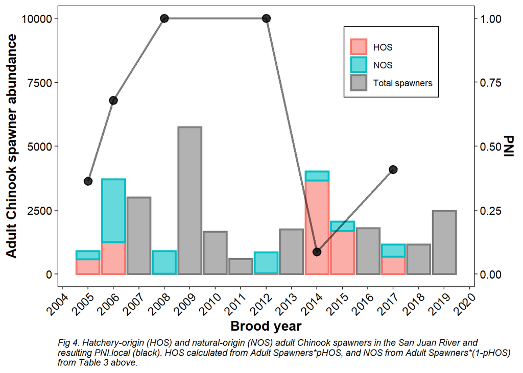

### **Recreational Catch**

#### Stock ID and origin

*Table 4. Stock ID methods used for Chinook sport catch.*

| YEAR | HATCHERY_ORIGIN | RESOLVED_STOCK_SOURCE2 | n |
| --- | --- | --- | --- |
| 2014 | unk | GSI (100%) | 4 |
|  | unk | GSI (70%) | 8 |
| 2015 | unk | GSI (100%) | 2 |
|  | unk | GSI (70%) | 11 |
|  | Y | OTO | 4 |
| 2016 | unk | GSI (100%) | 3 |
|  | unk | GSI (70%) | 3 |
|  | Y | CWT | 1 |
|  | Y | GSI (100%) | 1 |
|  | Y | OTO | 3 |
| 2017 | unk | GSI (100%) | 8 |
|  | unk | GSI (70%) | 17 |
|  | Y | CWT | 5 |
| 2018 | unk | GSI (100%) | 5 |
|  | unk | GSI (70%) | 24 |
|  | Y | CWT | 10 |
|  | Y | GSI (100%) | 1 |
|  | Y | GSI (70%) | 3 |
| 2019 | unk | GSI (100%) | 46 |
|  | unk | GSI (70%) | 35 |
|  | Y | CWT | 10 |
|  | Y | GSI (100%) | 3 |
|  | Y | GSI (70%) | 4 |
| 2020 | unk | GSI (100%) | 35 |
|  | unk | GSI (70%) | 23 |
|  | Y | CWT | 3 |
|  | Y | GSI (70%) | 2 |
|  | Y | PBT (uncertain) | 4 |
| 2021 | unk | GSI (100%) | 10 |
|  | unk | GSI (70%) | 20 |
|  | Y | CWT | 3 |
|  | Y | GSI (100%) | 3 |
|  | Y | OTO | 1 |
|  | Y | PBT (uncertain) | 12 |

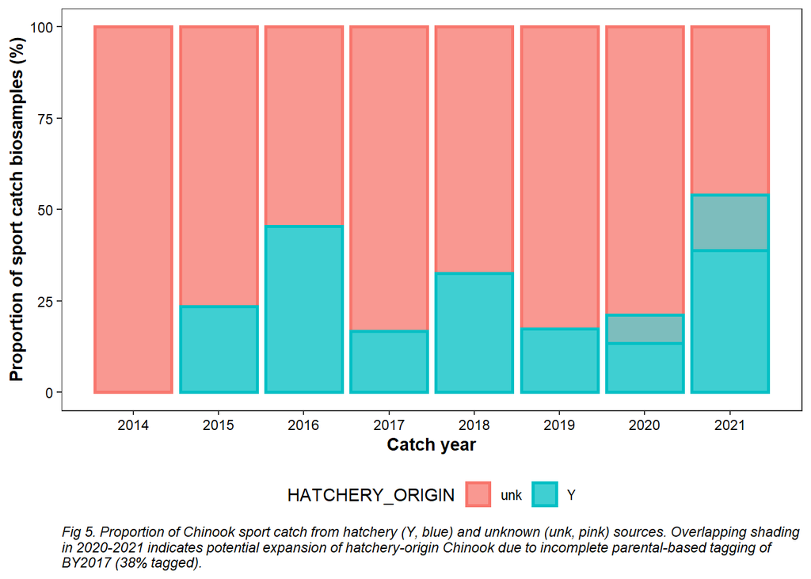

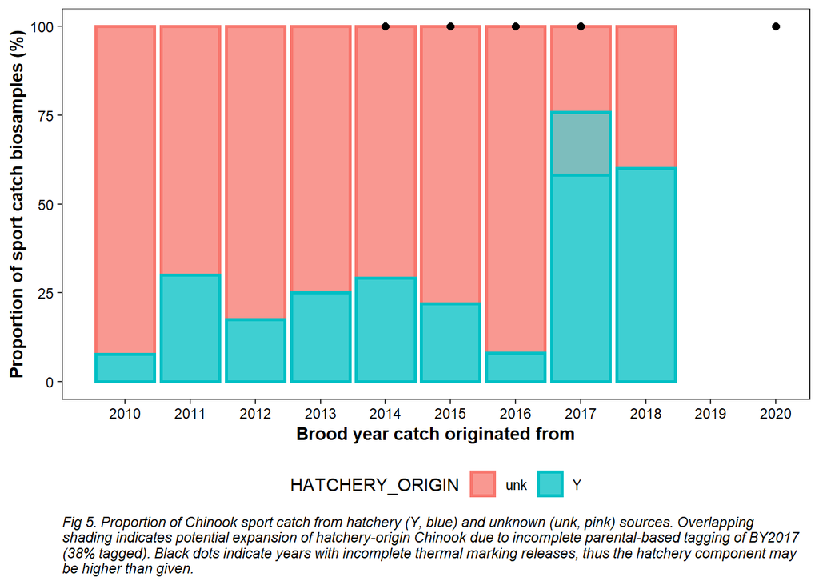

#### San Juan chinook recoveries

##### Otolith thermal mark recoveries

Most San Juan thermal marks have historically been recovered in escapement sampling. Few to no San Juan thermal marks have been recovered in sport fisheries as recorded in the Otolith Manager database.

*Table. All areas where San Juan otolith thermal marks have been recovered historically, extracted from Otolith Manager. ‘unk’ refers to otoliths submitted without a thermal mark. Corresponds to figure below.*

| SOURCE | SAMPLE.YR | total | RCVY.LOCATIONS | FACILITY2 | n | Proportion (%) |
| --- | --- | --- | --- | --- | --- | --- |
| Escapement | 2004 | 16 | 20 - Escape: SAN JUAN RIVER | SAN JUAN RIVER HATCHERY | 10 | 62 |
|  |  |  | 20 - Escape: SAN JUAN RIVER | unk | 6 | 38 |
|  | 2005 | 106 | 20 - Escape: SAN JUAN RIVER, 20 - PFMA: 20 | Other hatchery | 2 | 2 |
|  |  |  | 20 - Escape: SAN JUAN RIVER, 20 - PFMA: 20 | SAN JUAN RIVER HATCHERY | 63 | 59 |
|  |  |  | 20 - Escape: SAN JUAN RIVER, 20 - PFMA: 20 | unk | 41 | 39 |
|  | 2006 | 201 | 20 - Escape: SAN JUAN RIVER, 20 - PFMA: 20 | Other hatchery | 1 | 0 |
|  |  |  | 20 - Escape: SAN JUAN RIVER, 20 - PFMA: 20 | SAN JUAN RIVER HATCHERY | 66 | 33 |
|  |  |  | 20 - Escape: SAN JUAN RIVER, 20 - PFMA: 20 | unk | 134 | 67 |
|  | 2008 | 90 | 20 - Escape: SAN JUAN RIVER | Other hatchery | 1 | 1 |
|  |  |  | 20 - Escape: SAN JUAN RIVER | unk | 89 | 99 |
|  | 2012 | 102 | 20 - Escape: SAN JUAN RIVER | Other hatchery | 3 | 3 |
|  |  |  | 20 - Escape: SAN JUAN RIVER | unk | 99 | 97 |
|  | 2014 | 130 | 20 - Escape: SAN JUAN RIVER | Other hatchery | 7 | 5 |
|  |  |  | 20 - Escape: SAN JUAN RIVER | SAN JUAN RIVER HATCHERY | 111 | 85 |
|  |  |  | 20 - Escape: SAN JUAN RIVER | unk | 12 | 9 |
|  | 2015 | 95 | 20 - Escape: SAN JUAN RIVER | Other hatchery | 1 | 1 |
|  |  |  | 20 - Escape: SAN JUAN RIVER | SAN JUAN RIVER HATCHERY | 76 | 80 |
|  |  |  | 20 - Escape: SAN JUAN RIVER | unk | 18 | 19 |
|  | 2017 | 97 | 20 - Escape: SAN JUAN RIVER | SAN JUAN RIVER HATCHERY | 55 | 57 |
|  |  |  | 20 - Escape: SAN JUAN RIVER | unk | 42 | 43 |
|  | 2018 | 48 | 20 - PFMA: 20 | SAN JUAN RIVER HATCHERY | 6 | 12 |
|  |  |  | 20 - PFMA: 20 | unk | 42 | 88 |
|  | 2019 | 163 | 20 - Escape: SAN JUAN RIVER | Other hatchery | 43 | 26 |
|  |  |  | 20 - Escape: SAN JUAN RIVER | unk | 120 | 74 |
|  | 2020 | 244 | 20 - Escape: SAN JUAN RIVER | Other hatchery | 1 | 0 |
|  |  |  | 20 - Escape: SAN JUAN RIVER | SAN JUAN RIVER HATCHERY | 1 | 0 |
|  |  |  | 20 - Escape: SAN JUAN RIVER | unk | 242 | 99 |
|  | 2021 | 299 | 20 - Escape: SAN JUAN RIVER | Other hatchery | 2 | 1 |
|  |  |  | 20 - Escape: SAN JUAN RIVER | SAN JUAN RIVER HATCHERY | 15 | 5 |
|  |  |  | 20 - Escape: SAN JUAN RIVER | unk | 282 | 94 |
| FSC - Escapement | 2005 | 96 | 20 - Escape: SAN JUAN RIVER, 20 - PFMA: 20 | Other hatchery | 3 | 3 |
|  |  |  | 20 - Escape: SAN JUAN RIVER, 20 - PFMA: 20 | SAN JUAN RIVER HATCHERY | 53 | 55 |
|  |  |  | 20 - Escape: SAN JUAN RIVER, 20 - PFMA: 20 | unk | 40 | 42 |
|  | 2020 | 30 | 20 - Escape: SAN JUAN RIVER | unk | 30 | 100 |
| Other | 2003 | 37 | 20 - PFMA: 20 | Other hatchery | 2 | 5 |
|  |  |  | 20 - PFMA: 20 | unk | 35 | 95 |
| Sport | 2000 | 1 | 20 - PFMA: 20 | unk | 1 | 100 |
|  | 2003 | 15 | 20 - Creel: Port Renfrew | Other hatchery | 3 | 20 |
|  |  |  | 20 - Creel: Port Renfrew | unk | 12 | 80 |
|  | 2004 | 33 | 20 - Creel: Port Renfrew | Other hatchery | 12 | 36 |
|  |  |  | 20 - Creel: Port Renfrew | unk | 21 | 64 |
|  |  | 26 | 20 - PFMA: 20 | Other hatchery | 2 | 8 |
|  |  |  | 20 - PFMA: 20 | unk | 24 | 92 |
|  | 2009 | 131 | 20 - PFMA: 20 | unk | 131 | 100 |
|  | 2010 | 67 | 20 - PFMA: 20 | unk | 67 | 100 |
|  | 2011 | 49 | 20 - PFMA: 20 | unk | 49 | 100 |
|  | 2012 | 35 | 20 - PFMA: 20 | unk | 35 | 100 |
|  | 2013 | 58 | 20 - PFMA: 20 | unk | 58 | 100 |
|  | 2014 | 132 | 20 - PFMA: 20 | Other hatchery | 31 | 23 |
|  |  |  | 20 - PFMA: 20 | unk | 101 | 77 |
|  | 2015 | 177 | 0 - Creel: Area 20/21 RRA | Other hatchery | 57 | 32 |
|  |  |  | 0 - Creel: Area 20/21 RRA | SAN JUAN RIVER HATCHERY | 3 | 2 |
|  |  |  | 0 - Creel: Area 20/21 RRA | unk | 117 | 66 |
|  |  | 28 | 20 - PFMA: 20 | Other hatchery | 14 | 50 |
|  |  |  | 20 - PFMA: 20 | unk | 14 | 50 |
|  |  | 585 | 25 - Creel: Inner Nootka RRA | Other hatchery | 539 | 92 |
|  |  |  | 25 - Creel: Inner Nootka RRA | SAN JUAN RIVER HATCHERY | 1 | 0 |
|  |  |  | 25 - Creel: Inner Nootka RRA | unk | 45 | 8 |
|  | 2019 | 50 | 20 - Creel: Port Renfrew | Other hatchery | 7 | 14 |
|  |  |  | 20 - Creel: Port Renfrew | unk | 43 | 86 |
|  | 2020 | 228 | 20 - Creel: Port Renfrew | Other hatchery | 53 | 23 |
|  |  |  | 20 - Creel: Port Renfrew | unk | 175 | 77 |
|  | 2021 | 118 | 20 - Creel: Port Renfrew | Other hatchery | 20 | 17 |
|  |  |  | 20 - Creel: Port Renfrew | SAN JUAN RIVER HATCHERY | 1 | 1 |
|  |  |  | 20 - Creel: Port Renfrew | unk | 97 | 82 |

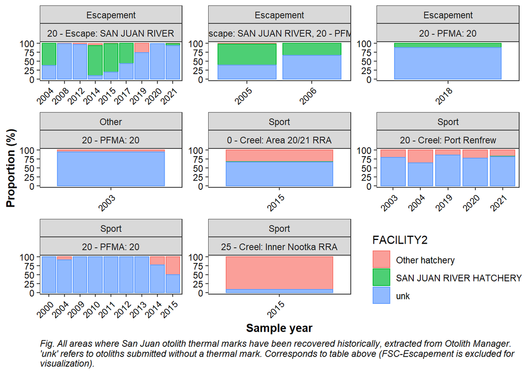

##### Recreational catch sample summary

| YEAR | total | region | n | propn |
| --- | --- | --- | --- | --- |
| 2014 | 294 | Fraser Summer 4.1 | 80 | 27 |
|  |  | US | 64 | 22 |
|  |  | SWVI | 50 | 17 |
|  |  | Fraser Summer 5.2 | 39 | 13 |
|  |  | Fraser Fall | 19 | 6 |
|  |  | Fraser Spring 5.2 | 19 | 6 |
|  |  | NA | 11 | 4 |
|  |  | NWVI | 6 | 2 |
|  |  | ECVI Fall | 3 | 1 |
|  |  | Fraser Spring 4.2 | 3 | 1 |
| 2015 | 256 | SWVI | 81 | 32 |
|  |  | Fraser Summer 4.1 | 74 | 29 |
|  |  | US | 56 | 22 |
|  |  | NWVI | 21 | 8 |
|  |  | NA | 9 | 4 |
|  |  | Fraser Spring 5.2 | 4 | 2 |
|  |  | Fraser Summer 5.2 | 6 | 2 |
|  |  | ECVI Fall | 3 | 1 |
|  |  | Fraser Fall | 2 | 1 |
| 2016 | 244 | US | 79 | 32 |
|  |  | SWVI | 64 | 26 |
|  |  | Fraser Summer 4.1 | 53 | 22 |
|  |  | NA | 31 | 13 |
|  |  | NWVI | 7 | 3 |
|  |  | ECVI Fall | 4 | 2 |
|  |  | Fraser Fall | 2 | 1 |
|  |  | Fraser Summer 5.2 | 3 | 1 |
|  |  | Fraser Spring 5.2 | 1 | 0 |
| 2017 | 470 | US | 156 | 33 |
|  |  | NA | 105 | 22 |
|  |  | Fraser Summer 4.1 | 90 | 19 |
|  |  | SWVI | 84 | 18 |
|  |  | ECVI Fall | 10 | 2 |
|  |  | Fraser Spring 5.2 | 9 | 2 |
|  |  | Fraser Fall | 3 | 1 |
|  |  | Fraser Summer 5.2 | 6 | 1 |
|  |  | NWVI | 5 | 1 |
|  |  | Fraser Spring 4.2 | 2 | 0 |
| 2018 | 471 | US | 163 | 35 |
|  |  | Fraser Summer 4.1 | 116 | 25 |
|  |  | SWVI | 104 | 22 |
|  |  | NA | 51 | 11 |
|  |  | Fraser Spring 5.2 | 10 | 2 |
|  |  | Fraser Summer 5.2 | 11 | 2 |
|  |  | ECVI Fall | 5 | 1 |
|  |  | Fraser Fall | 7 | 1 |
|  |  | NWVI | 3 | 1 |
|  |  | NEVI | 1 | 0 |
| 2019 | 322 | Fraser Summer 4.1 | 143 | 44 |
|  |  | SWVI | 98 | 30 |
|  |  | US | 60 | 19 |
|  |  | NA | 12 | 4 |
|  |  | ECVI Fall | 3 | 1 |
|  |  | Fraser Fall | 4 | 1 |
|  |  | Fraser Summer 5.2 | 2 | 1 |
| 2020 | 219 | Fraser Summer 4.1 | 79 | 36 |
|  |  | SWVI | 66 | 30 |
|  |  | US | 49 | 22 |
|  |  | NA | 8 | 4 |
|  |  | ECVI Fall | 6 | 3 |
|  |  | NEVI | 3 | 1 |
|  |  | NWVI | 3 | 1 |
|  |  | Fraser Fall | 1 | 0 |
|  |  | Fraser Spring 4.2 | 1 | 0 |
|  |  | Fraser Spring 5.2 | 1 | 0 |
|  |  | Fraser Summer 5.2 | 1 | 0 |
|  |  | NANAIMO_RIVER_fall (Stock Rollup Not Found) | 1 | 0 |
| 2021 | 326 | Fraser Summer 4.1 | 125 | 38 |
|  |  | SWVI | 98 | 30 |
|  |  | US | 56 | 17 |
|  |  | NA | 31 | 10 |
|  |  | Fraser Summer 5.2 | 5 | 2 |
|  |  | ECVI Fall | 4 | 1 |
|  |  | Fraser Fall | 4 | 1 |
|  |  | Fraser Spring 5.2 | 1 | 0 |
|  |  | NWVI | 1 | 0 |
|  |  | S Mainland Inlets | 1 | 0 |

Otolith thermal marks are not the only means of identifying where San Juan chinook are recovered, but to date methods are limited as PBT is very new, and only a fraction of releases are adipose-clipped/CWT’d.

[figure not shown]

```r
ggplot(data=sj.crestrcvy.AAs%>% filter(origin_rollup!="Other/unk"), aes(x=YEAR, y=propn, fill=origin_rollup, colour=origin_rollup)) +
  geom_bar(stat="identity", position="stack", alpha=0.5) +
  labs(x="Catch year", y="Proportion of sport catch biosamples (%)", caption="Fig. Proportion of San Juan/Port Renfrew chinook caught in all recreational fisheries. Note they constitute <10% of \ncatch in any given year. Data from a random sample of chinook identified by CWT, otolith thermal marks and/or DNA \nfrom CREST.") +
  scale_y_continuous(limits=c(0,15)) +
  theme_bw() +
  theme(panel.grid = element_blank(),
        axis.text.x = element_text(angle=45, hjust=1, colour="black"),
        axis.text = element_text(colour="black"),
        axis.title = element_text(face="bold"),
        plot.caption = element_text(hjust=0, face="italic")) +
  facet_wrap(.~AREA)
```